# Thermal drift correction using the thermal package

# Introduction

The `thermal` package was designed to correct for the effect of drift in thermal infrared (TIR) images obtained using uncooled cameras mounted on unmanned aerial vehicles (UAVs). Indeed, the sensor arrays of these cameras are sensitive to variation in both internal (heat produced by functioning camera) and external (temperature, wind, radiation, and other meteorological phenomena) conditions. As a result, data retrieved by these cameras will vary due to factors other than the temperature of the surfaces being surveyed, which is usually the variable that users intend to measure. This artefactual variation in the intensity of TIR radiation recorded by cameras over time is termed *drift*.

`thermal` provides functions for reading TIR images and their metadata, correcting thermal drift using various underlying models, as well as a few other functions that may be more generally useful to users of UAV-derived TIR data. This vignette will focus on getting users started with processing TIR data and correcting drift using various models. The underlying assumptions and limitations of the models will be explained so that users can pick the approach that appears to be the best for their use case.

# Test dataset

As part of this vignette, we will use a set of 30 TIR images taken around noon on September 1, 2023. The UAV flew over a jack pine (*Pinus banksiana*) forest but the area surveyed also includes a gravel/sand road and a parked pick-up truck. Three aluminum panels painted with different colors (black, gray and white) were also included to provide reference surfaces whose temperature was measured in real time for benchmarking purposes.

The images were downgraded from their original 640x512 resolution to 80x64 to reduce their size for shipping along with the package and speed up processing for testing purposes. While the quality of the images is reduced, this is of little relevance to the examples presented in this vignette.

The images can be accessed through the `system.file` function, which accesses files shipped within a package:

```r
# Loading the package
library(thermal)

# Getting a vector of absolute paths to the test TIR images
thermal_files <- dir(system.file("extdata", package = "thermal"),
                     pattern = "thermal\\.tiff$", full.names = TRUE)

head(thermal_files)
```

```
#> [1] "/tmp/RtmpA3E5Zt/temp_libpath670a3e13abfe/thermal/extdata/DJI_0665_thermal.tiff"
#> [2] "/tmp/RtmpA3E5Zt/temp_libpath670a3e13abfe/thermal/extdata/DJI_0671_thermal.tiff"
#> [3] "/tmp/RtmpA3E5Zt/temp_libpath670a3e13abfe/thermal/extdata/DJI_0677_thermal.tiff"
#> [4] "/tmp/RtmpA3E5Zt/temp_libpath670a3e13abfe/thermal/extdata/DJI_0683_thermal.tiff"
#> [5] "/tmp/RtmpA3E5Zt/temp_libpath670a3e13abfe/thermal/extdata/DJI_0689_thermal.tiff"
#> [6] "/tmp/RtmpA3E5Zt/temp_libpath670a3e13abfe/thermal/extdata/DJI_0695_thermal.tiff"
```

The exact paths will differ depending on the location of the `thermal` installation on your machine.

The first four images of the dataset look as follows:

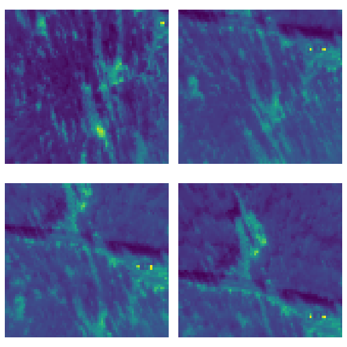

# Reading image metadata

Many operations in the `thermal` package access the images through their metadata instead of directly through the image files. Metadata is stored within the image files as EXIF tags which can be read through functionality provided by the [exifr](https://cran.r-project.org/web/packages/exifr/index.html) package. The function `read_metadata` allows to read the metadata on a set of UAV-derived images by providing a vector of file paths. It serves as a starting point for any analysis involving the `thermal` package:

```r
# Reading metadata from EXIF tags
tmeta_df <- read_metadata(thermal_files,
                          camera_tz = "Etc/GMT+5",
                          display_tz = "Etc/GMT+4",
                          tags = "minimal")

str(tmeta_df)
```

```
#> 'data.frame':    30 obs. of  11 variables:
#>  $ SourceFile      : chr  "/tmp/RtmpA3E5Zt/temp_libpath670a3e13abfe/thermal/extdata/DJI_0665_thermal.tiff" "/tmp/RtmpA3E5Zt/temp_libpath670a3e13abfe/thermal/extdata/DJI_0671_thermal.tiff" "/tmp/RtmpA3E5Zt/temp_libpath670a3e13abfe/thermal/extdata/DJI_0677_thermal.tiff" "/tmp/RtmpA3E5Zt/temp_libpat…
#>  $ GimbalYawDegree : num  166.2 -179.5 -178.6 -178.4 -92.7 ...
#>  $ CreateDate      : POSIXct, format: "2023-09-01 11:59:34" "2023-09-01 11:59:47" ...
#>  $ DateTimeOriginal: POSIXct, format: "2023-09-01 11:59:34" "2023-09-01 11:59:47" ...
#>  $ GPSLongitudeRef : chr  "W" "W" "W" "W" ...
#>  $ GPSLatitudeRef  : chr  "N" "N" "N" "N" ...
#>  $ GPSAltitudeRef  : int  0 0 0 0 0 0 0 0 0 0 ...
#>  $ GPSLongitude    : num  -78.2 -78.2 -78.2 -78.2 -78.2 ...
#>  $ GPSLatitude     : num  48.5 48.5 48.5 48.5 48.5 ...
#>  $ GPSAltitude     : num  336 336 336 336 336 ...
#>  $ GPSMapDatum     : chr  "WGS84" "WGS84" "WGS84" "WGS84" ...
```

The value returned is a data.frame with as many rows as there are images in the dataset and various metadata variables as columns. The `tags` argument to `read_metadata` specifies which tags should be read from the files. This can be either a character vector of tags to read or one of a few keywords which result in a predetermined set of tags being read. Here, the value `"minimal"` indicates that only the tags that are deemed minimally necessary for further processing by `thermal` should be read. By default, all tags will be read, but this will be significantly slower as this operation is intensive in terms of disk input/output.

The time zone arguments `camera_tz` (mandatory) and `display_tz` (optional) influence how time will be represented in the metadata. Here, the camera wrote the time stamps based on the Eastern Standard Time (`"Etc/GMT+5"`) but the local time when the images were taken was actually Eastern Daylight Time (`"Etc/GMT+4"`). Therefore, to simplify downstream analyses, we force the metadata to be represented using this time zone.

As can be seen from the structure of the dataset above, the data.frame returned by `read_metadata` using `tags = "minimal"` contains information about the paths to the image files, the time when the images were taken, as well as the orientation and geographic location of the drone when the picture was taken. That is all the information the `thermal` package really needs to go forward, but some users may want to extract more information depending on their particular needs.

The `plot_metadata` function takes a dataset created with `read_metadata` and shows a very basic layout of the locations where the flight pictures were taken. We can see that our survey area is approximately square-shaped and consists of eight flight lines:

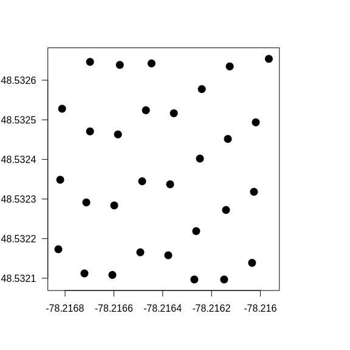

```r
# If base_crs is not set, it will be set to WGS84 (EPSG:4326) with a warning
plot_metadata(tmeta_df, base_crs = sf::st_crs("EPSG:4326"))
```

Some parameters are available to gain more control over the output of `plot_metadata` or plot additional features. For example, an alternative coordinate reference system (CRS) may be specified to transform the data prior to plotting. This can be useful to represent the coordinates in meters instead of degrees.

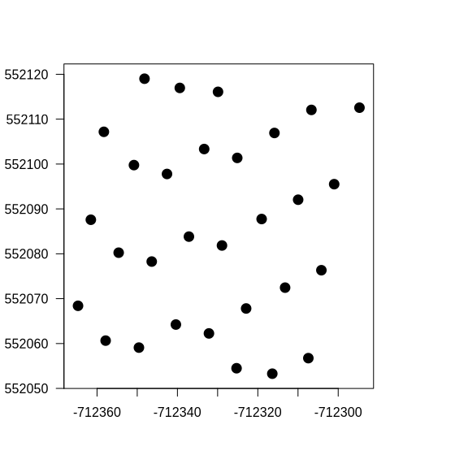

```r
plot_metadata(tmeta_df, base_crs = sf::st_crs("EPSG:4326"), new_crs = sf::st_crs("EPSG:32198"))
```

Arrows representing the trajectory of the drone can also be added:

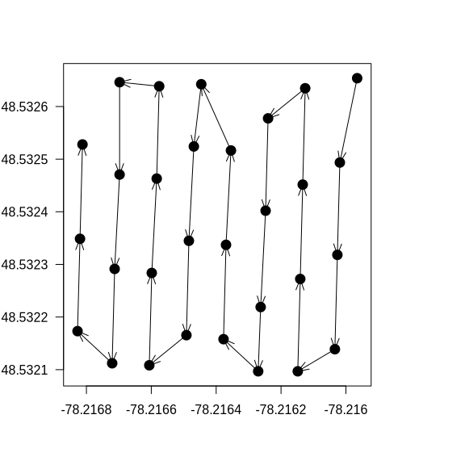

```r
plot_metadata(tmeta_df, base_crs = sf::st_crs("EPSG:4326"),
              arrows = TRUE, arrow_angle = 20,
              arrow_length = grid::unit(0.15, "inches"))
```

The points can be colored according to a factor, here for example the points are colored according to the direction that the drone is going towards:

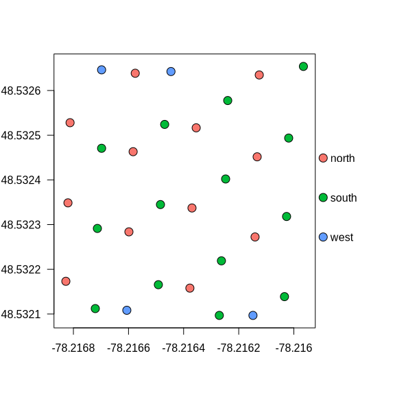

```r
bearing <- ifelse(abs(tmeta_df$GimbalYawDegree) > 150, "south",
                  ifelse(abs(tmeta_df$GimbalYawDegree) < 50, "north", "west"))

plot_metadata(tmeta_df, base_crs = sf::st_crs("EPSG:4326"), color = as.factor(bearing))
```

Finally, a numeric vector can also be provided as the `color` argument to map those numeric values to a color scale:

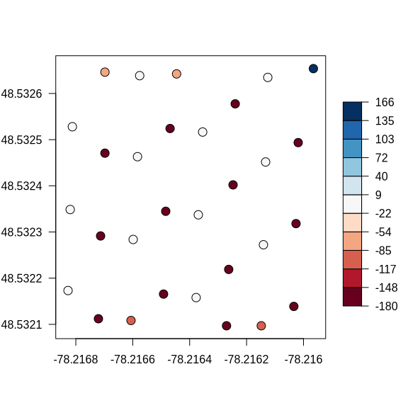

```r
plot_metadata(tmeta_df, base_crs = sf::st_crs("EPSG:4326"), color = tmeta_df$GimbalYawDegree)
```

# Computing metrics on images

Once metadata has been read, several downstream analyses are possible. One that is of particular interest in the context of thermal drift is the mean value of all pixels in the thermal images over time. While this mean value is likely to vary due to actual temperature differences over the area being surveyed, drift will result in sudden or gradual changes in the mean value of the images over time. The function `thermal_mean` accepts a data.frame of metadata and returns a vector of numeric values corresponding to the mean value of each image.

```r
# We store the mean of each image as a new column in the metadata data.frame
tmeta_df$mean <- thermal_mean(tmeta_df)
```

While the data.frame does not contain information on the image pixels themselves, the `SourceFile` column allows to get the path to the image. It is therefore preferable for metadata to be read using absolute paths; this way, the path to the images remains valid no matter what the working directory is.

By looking at the trend in the mean over time, we can identify possible drift patterns. We can see a few sudden drops that might indicate the occurrence of non-uniformity correction (NUC) events that resulted in the values recorded by the camera to suddenly change. The package provides the `plot_drift` function to view the changes in image mean over time.

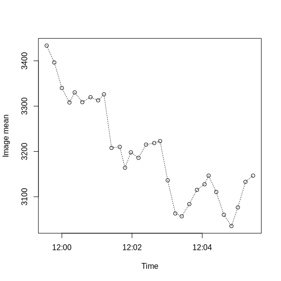

```r
plot_drift(tmeta_df)
```

Another interesting pattern to look at is that of the mean value recorded by each individual pixel over time. While this dataset is a bit small for that purpose, larger datasets can provide insights into potential vignetting using this approach. Indeed, if a large number of pictures were taken over a relatively uniform landscape, then we would expect the average of each pixel to be similar across the sensor array. If that is not the case, this may indicate that some pixels consistently record higher or lower values, i.e. that vignetting is occurring. The function `compute_vignetting` computes the pixel-wise average over the flight and is so-named because it provides insights into possible vignetting patterns:

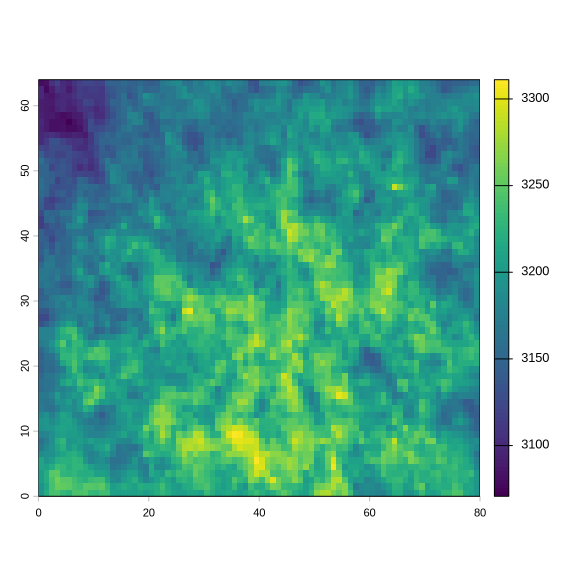

```r
vignetting <- compute_vignetting(tmeta_df)
terra::plot(vignetting)
```

This dataset is not quite large enough to confidently identify vignetting patterns, but the data suggest that center pixels tend to display higher values while edge pixels display lower values.

# Drift correction

The `thermal` package provides four methods for correcting drift, each of which has its own assumptions and limitations. In this section, we will go over each of the correction approaches, but first we will discuss how these functions are implemented as they share a common backbone in how the code is structured.

## Implementation of drift correction in the `thermal` package

Conceptually, drift correction aims at removing artefactual variation in thermal values recorded by the camera while preserving variation due to actual differences in surface temperature. Therefore, all correction approaches implement some kind of model (statistical or empirical) that allows to differentiate between those two components of TIR variation over time.

The function `correct_thermal` offers a unified interface for thermal drift correction to users of the `thermal` package. While the underlying mechanics of the correction approaches differ, all approches aim to quantify the differences due to drift between each picture and a reference picture. These differences, which we call *adjustment factors* in `thermal` parlance, are then added to or subtracted from all pixels in an image provide a corrected image. That is really all there is to it: adjustment factors are computed under a given model and then used to adjust the values of all pixels in each image. The reference picture can be provided explicitly by the user, but by default, the image used as a reference will be taken from the middle of the flight (e.g. the 50th image in a 100-image flight).

Once adjustment factors have been computed based on some model, `correct_thermal` reads the image source files from disk, corrects them, and saves them elsewhere on disk. The reason why `thermal` uses disk storage instead of storing the correction results in-memory is that memory usage could potentially exceed the RAM available on the system when processing large datasets. As part of the examples presented here, a temporary directory will be used to save the results. However, in real-life usage, users should create a directory (separate from the one where the source files are located) to store the corrected images. `correct_thermal` will save the corrected files as TIFF files by replacing (if necessary) the extension of the source files and saving the corrected images to the directory provided by the user. In the current version of `thermal`, there is no way to control output file names or format beyond this default, but files can be renamed or converted after correction.

Importantly, EXIF metadata tags need to be transferred to the corrected image files so that metadata (e.g. time and geographical position) are preserved. This will be important for users aiming to perform downtream analyses such as generating an orthomosaic from the corrected images.

Despite storing the correction results to disk instead of in-memory, `correct_thermal` will return a data.frame of metadata on the newly corrected data. This allows for downstream analyses to be done seamlessly on the corrected images.

## Drift correction based on overall mean adjustement

The simplest correction model assumes that all variation in the mean of TIR values between pictures is due to drift. While this model is almost certainly wrong, especially if there is significant variation in land surface features over the duration of the flight, it provides a good starting point for discussing drift correction approaches.

Under this model, correction essentially consists in drawing a line through all points in the plot of the mean values of thermal pictures throughout time, and then assuming that all variation due to drift is represented by that line. This line is indeed exactly the same as is shown using `plot_drift`:

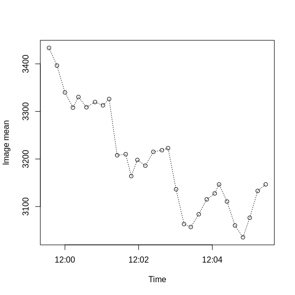

```r
plot_drift(tmeta_df)
```

Drift correction under the overall mean adjustment model can be run using the following commands:

```r
# Creating a temporary directory to write the corrected images to
# Normally users will use a directory on persistent storage for retrieval later
tmpdir <- tempdir()

# Running correct_thermal on the test data
# Time zone arguments need to be provided again because EXIF tags are
# transferred unmodified from the source files to the corrected files
overall_tmeta <- correct_thermal(metadata = tmeta_df,
                                 correction_type = "overall",
                                 output_dir = tmpdir,
                                 camera_tz = "Etc/GMT+5",
                                 display_tz = "Etc/GMT+4",
                                 tags = "minimal",
                                 overwrite_dst = TRUE)
```

```
#> Processing index 1 with adjustment = -218.5078125
#> Processing index 2 with adjustment = -181.31796875
#> Processing index 3 with adjustment = -124.9265625
#> Processing index 4 with adjustment = -93.0316406249999
#> Processing index 5 with adjustment = -115.21328125
#> Processing index 6 with adjustment = -93.7181640624999
#> Processing index 7 with adjustment = -104.64609375
#> Processing index 8 with adjustment = -97.7357421874999
#> Processing index 9 with adjustment = -111.0201171875
#> Processing index 10 with adjustment = 7.22304687499991
#> Processing index 11 with adjustment = 4.9755859375
#> Processing index 12 with adjustment = 51.0675781249997
#> Processing index 13 with adjustment = 17.0882812499999
#> Processing index 14 with adjustment = 29.1435546875
#> Processing index 15 with adjustment = 0
#> Processing index 16 with adjustment = -3.455078125
#> Processing index 17 with adjustment = -7.7158203125
#> Processing index 18 with adjustment = 78.7705078125
#> Processing index 19 with adjustment = 151.9712890625
#> Processing index 20 with adjustment = 158.2025390625
#> Processing index 21 with adjustment = 131.2736328125
#> Processing index 22 with adjustment = 99.9367187499997
#> Processing index 23 with adjustment = 87.5498046875
#> Processing index 24 with adjustment = 68.5626953124997
#> Processing index 25 with adjustment = 104.4912109375
#> Processing index 26 with adjustment = 154.815625
#> Processing index 27 with adjustment = 179.7009765625
#> Processing index 28 with adjustment = 138.70546875
#> Processing index 29 with adjustment = 82.1187500000001
#> Processing index 30 with adjustment = 68.5484375000001
#> 'exiftool' -overwrite_original -tagsFromFile /tmp/RtmpA3E5Zt/temp_libpath670a3e13abfe/thermal/extdata/%f.tiff -GimbalYawDegree -CreateDate -DateTimeOriginal -GPSLongitudeRef -GPSLatitudeRef -GPSAltitudeRef -GPSLongitude -GPSLatitude -GPSAltitude -GPSMapDatum '/tmp/RtmpLAyysz'
```

By default, `correct_thermal` will print out messages informing users about the adjustment factors applied to each image. Here, we can see that the image used as a reference (the `midpoint` image), which is index 15, effectively has an adjustment factor of 0. While we do encourage users to look at these messages in interactive usage with real-world data, we will suppress this behaviour for the remainder of this vignette using the argument `verbose = FALSE`.

If we look at the trend in the mean of images over time for the corrected dataset, we can see that the mean is now nearly constant over time. This is expected under this model because we assume that all variation in the mean value of images is due to drift. All we did is essentially bring the mean value of all pictures on par with that of the reference picture. By looking at the plot, we can see minor variation in the mean of pictures over time due to the fact that thermal values are stored on disk as integers, and some precision is therefore lost. However, this variation (less than 1) is insignificant relative to the scale of the measurements.

```
#> Computing thermal image means on the fly as they were not pre-computed...
```

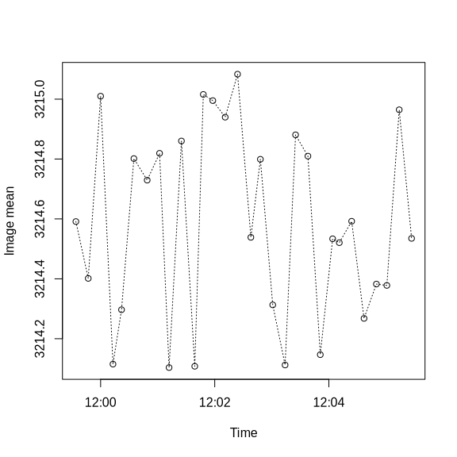

```r
plot_drift(overall_tmeta)
```

## Drift correction based on statistical models

The overall mean correction described above was a good introduction to the correction framework used by `thermal`, however it is unlikely to be a good solution for most real-world datasets as its assumptions are almost certainly wrong. A better approach is to try and model thermal drift using statistical models of mean thermal values over time and use those models of drift to compute the adjustment factors.

As noted earlier, drift can occur gradually due to variation in sensor sensitivity, but also sometimes suddenly due to NUC events triggered by the camera firmware. Statistical models of drift need to differentiate between those two sources of variation. To solve this problem, we chose to fit a distinct statistical model to each flight segment occurring between two NUC events. The rationale for this choice is that we assume that variation in thermal values can be described statistically within the timespan of camera settings defined by NUC, but not across different NUC settings.

This raises the question of how to define NUC events. We adopted a simple approach that considers any difference in the mean of successive thermal images over a fixed threshold as a NUC event. The package uses a default NUC threhsold of 50, however, this threshold is controllable as the parameter `nuc_threshold` in `correct_thermal` and should be assessed on a case-by-case basis depending on the nature of the dataset.

For the purposes of this vignette, we used a threshold of 80 to define NUC events. These are represented as red lines in the following plot, which can be obtained by setting the `nuc_threshold` parameter in `plot_drift`:

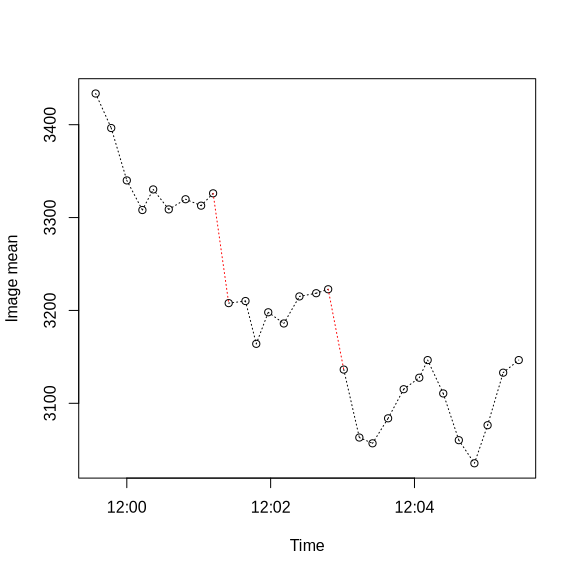

```r
plot_drift(tmeta_df, nuc_threshold = 80)
```

Based on a threshold of 80, we can therefore see that three flight segments are identified as separated by NUC events. Correction approaches based on the statistical modelling of thermal drift will therefore fit three distinct models to this data.

### Drift correction based on a linear model of thermal drift

The simplest statistical models to use for representing drift are linear models. This approach assumes that drift varies linearly with time in-between NUC events. The function `plot_fit` shows how a statistical model would fit the drift pattern, here using `method = "lm"` for linear models:

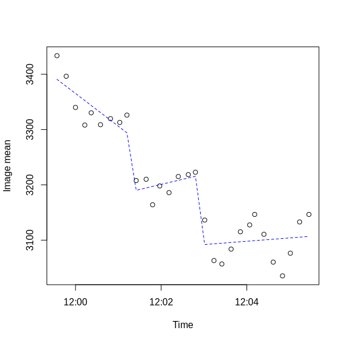

```r
plot_fit(tmeta_df, nuc_threshold = 80, method = "lm")
```

Differences between observed values and predicted values (i.e., model residuals) are taken to represent genuine variation in TIR values and will be preserved in the corrected data. The variation indicated by the blue line is otherwise considered indicative of drift and will be used to compute the adjustment factors for data correction.

Users need not to know the fine details of how to compute these linear models and can simply provide the `correction_type = "lm"` argument to `correct_thermal`.

```r
lm_tmeta <- correct_thermal(metadata = tmeta_df,
                            correction_type = "lm",
                            output_dir = tmpdir,
                            camera_tz = "Etc/GMT+5",
                            display_tz = "Etc/GMT+4",
                            tags = "minimal",
                            nuc_threshold = 80,
                            overwrite_dst = TRUE,
                            verbose = FALSE)
```

The plot of the mean of corrected images now looks as follows:

```
#> Computing thermal image means on the fly as they were not pre-computed...
```

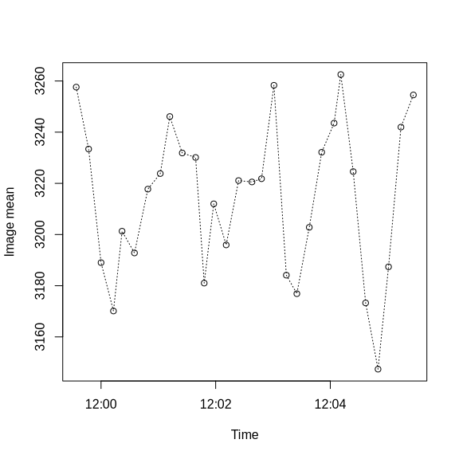

```r
plot_drift(lm_tmeta)
```

This variation is somewhat more realistic than what was obtained from the output of the overall mean model.

### Drift correction based on a cubic spline model of thermal drift

Instead of a linear model, a cubic spline can also be used to model the thermal drift in-between NUC events. This allows for the drift model to more closely follow variations in the data. In practice, this results in a correction that is somewhat a hybrid between the overall mean and linear model approaches, in that it attributes less variation to drift than the former, but more than the latter. Setting `method = "spline"` in `plot_fit` shows how a set of splines would fit our dataset:

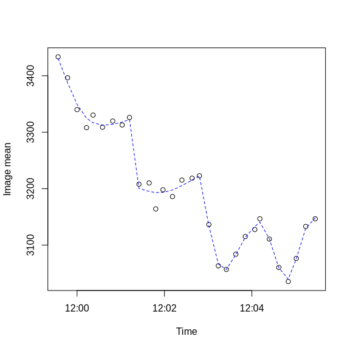

```r
plot_fit(tmeta_df, nuc_threshold = 80, method = "spline")
```

As seen above, by default, the smoothing spline will fit the data rather closely. A more parsimonious fit can be obtained by setting the smoothing parameter through `spline_spar`, which is eventually passed to the `spar` parameter of function `stats::smooth.spline`. For example, `spline_spar = 0.5` yields the following fit:

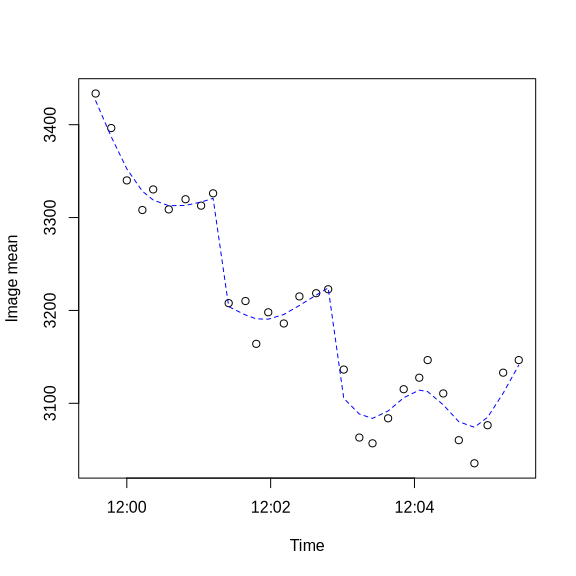

```r
plot_fit(tmeta_df, nuc_threshold = 80, method = "spline", spline_spar = 0.5)
```

We will use this last value (`spline_spar = 0.5`) for image correction. Applying this correction method using `correct_thermal` is fairly easy using the `correction_type = "spline"` argument:

```r
spline_tmeta <- correct_thermal(metadata = tmeta_df,
                                correction_type = "spline",
                                spline_spar = 0.5,
                                output_dir = tmpdir,
                                camera_tz = "Etc/GMT+5",
                                display_tz = "Etc/GMT+4",
                                tags = "minimal",
                                nuc_threshold = 80,
                                overwrite_dst = TRUE,
                                verbose = FALSE)
```

The plot of the mean of corrected images looks as follows after using spline correction:

```
#> Computing thermal image means on the fly as they were not pre-computed...
```

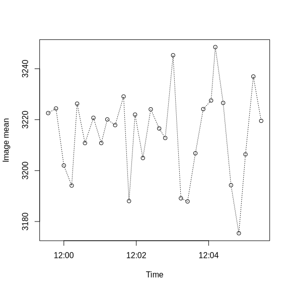

```r
plot_drift(spline_tmeta)
```

The variation in mean over time is fairly restricted, but not quite as much as when using correction based on overall mean.

## Drift correction based on image overlap

The `thermal` package provides another correction method which is very different in that it is not based on a statistical model of thermal drift. Instead, it uses an intuitive approach to compute the adjustment factors based on the overlap between successive pictures in a dataset.

This approach assumes that essentially no variation in surface temperature (and therefore, in the amount of TIR radiation emitted by those surfaces) occurs in between the few seconds that separate two successive images. Therefore, by computing the mean value of perceived TIR in the image sections that do overlap, it should be possible to compute just how much drift has occured between pictures, as the surface captured is the same in both sections.

### Finding the overlaps between images

The correction based on image overlap is by far the most computing-intensive method as it first needs to determine the sections of images that overlap. To find these overlapping sections, the `thermal` package needs a formal description of how the coordinates of an image can be translated to the coordinates of a neighbouring one using a geometric transformation that combines a rotation and a translation. This is modeled using three transformation parameters:

- *theta*, the angle of rotation (in degrees) between sucessive pictures
- *htrans*, the horizontal translation (in pixels) between successive pictures
- *vtrans*, the vertical translation (in pixels) between successive pictures

These transformation parameters need to be estimated for each pair of successive pictures in a dataset. Therefore, for the 30 pictures in our dataset, 29 sets of transformation parameters need to be estimated.

The function `optimize_transform` provides the functionality to compute those parameters. Under the hood, it first tries various parameter combinations based on a brute-force approach and then passes on the best parameter combination to `stats::optim` to refine the estimates. The metric that it aims to optimize is the correlation between the pixel values of two pictures for which we want to find the transformation parameters. Many parameters are available to control the optimization procedure and we highly encourage users who intend to use this approach to carefully read the function’s documentation. Here, we will simply show a glimpse of the available functionality. The next code chunk shows the estimation of the transformation parameters for the first two pictures in the dataset.

```r
# We can provide a first guess of what the rotation will be based on the
# difference in gimbal yaw angle recorded by the camera at the two time points
theta_guess <- -(tmeta_df[2, "GimbalYawDegree"] - tmeta_df[1, "GimbalYawDegree"])

trans_params <- optimize_transform(x = terra::rast(tmeta_df[1, "SourceFile"]),
                                   y = terra::rast(tmeta_df[2, "SourceFile"]),
                                   theta1 = theta_guess,
                                   reltol = 10^-3)
```

```
#> Initial guess: cor = 0.113956883604229
#> Current best parameters: theta = 345.699997, htrans = 0, vtrans = 0
#> Running iteration 1 of find_initial on 225 values.
#> find_initial iteration 1: cor = 0.575810814551184
#> Current best parameters: theta = 344.449997, htrans = 10, vtrans = 20
#> Running iteration 2 of find_initial on 1800 values.
#> find_initial iteration 2: cor = 0.388029308405845
#> Current best parameters: theta = 344.449997, htrans = 10, vtrans = 20
#>   Nelder-Mead direct search function minimizer
#> function value for initial parameters = -0.575811
#>   Scaled convergence tolerance is 0.000576811
#> Stepsize computed as 34.445000
#> BUILD              4 0.072628 -0.575811
#> LO-REDUCTION       6 0.020040 -0.575811
#> LO-REDUCTION       8 -0.040663 -0.575811
#> LO-REDUCTION      10 -0.098552 -0.575811
#> SHRINK            15 0.077197 -0.575811
#> HI-REDUCTION      17 -0.144251 -0.575811
#> HI-REDUCTION      19 -0.231527 -0.575811
#> HI-REDUCTION      21 -0.347468 -0.575811
#> HI-REDUCTION      23 -0.353645 -0.575811
#> HI-REDUCTION      25 -0.412647 -0.575811
#> LO-REDUCTION      27 -0.442970 -0.639053
#> HI-REDUCTION      29 -0.485450 -0.639053
#> LO-REDUCTION      31 -0.557173 -0.688199
#> HI-REDUCTION      33 -0.575811 -0.693340
#> HI-REDUCTION      35 -0.639053 -0.739501
#> HI-REDUCTION      37 -0.688199 -0.768386
#> HI-REDUCTION      39 -0.693340 -0.768386
#> LO-REDUCTION      41 -0.739501 -0.776290
#> LO-REDUCTION      43 -0.763341 -0.781190
#> REFLECTION        45 -0.768386 -0.793087
#> LO-REDUCTION      47 -0.776290 -0.808631
#> HI-REDUCTION      49 -0.781190 -0.812372
#> REFLECTION        51 -0.793087 -0.817684
#> HI-REDUCTION      53 -0.808631 -0.818568
#> REFLECTION        55 -0.812372 -0.828142
#> LO-REDUCTION      57 -0.817684 -0.828142
#> HI-REDUCTION      59 -0.818568 -0.828508
#> HI-REDUCTION      61 -0.825035 -0.828508
#> HI-REDUCTION      63 -0.825626 -0.828559
#> LO-REDUCTION      65 -0.827287 -0.828559
#> LO-REDUCTION      67 -0.827766 -0.828559
#> SHRINK            72 -0.827357 -0.829481
#> LO-REDUCTION      74 -0.828559 -0.830475
#> LO-REDUCTION      76 -0.828638 -0.830475
#> LO-REDUCTION      78 -0.829481 -0.830475
#> HI-REDUCTION      80 -0.829540 -0.830475
#> Exiting from Nelder Mead minimizer
#>     82 function evaluations used
#> Final best parameters: theta = 346.996722153049, htrans = 9.26875532630485, vtrans = 17.1389747954261
#> Final cor: 0.830475136725157
```

The package provides the `check_transform` function to visually verify the accuracy of transformation parameters. This function works best in interactive mode, where the user is queried for clicks on the source image and the location of the transformed coordinates is drawn on the target image. This way, the location of features of interest can be verified. Otherwise, a number of coordinates are randomly sampled and shown using distinct colors on both images. In all cases, the oultine of the images relative to each other are shown using a red box. In the following plot, we can see that the transformation parameters are reasonably accurate.

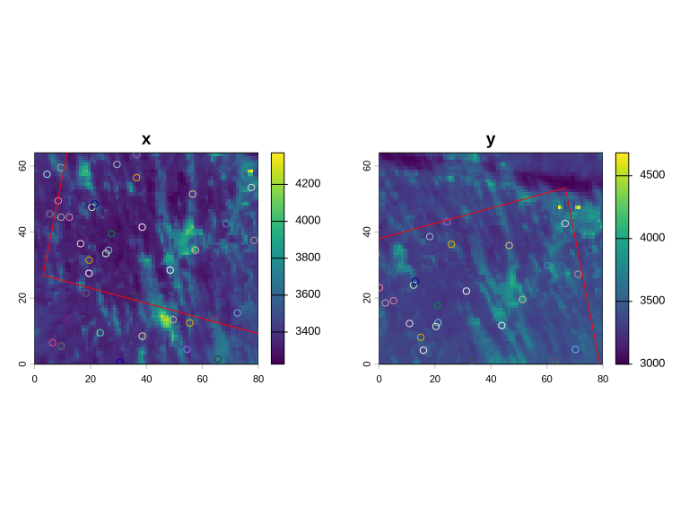

```r
# Setting the seed for reproducibility of the vignette
set.seed(1)

# Verifying the transformation parameters non-interactively
check_transform(x = terra::rast(tmeta_df[1, "SourceFile"]),
                y = terra::rast(tmeta_df[2, "SourceFile"]),
                params = trans_params, n = 40)
```

We will need the transformation parameters for the whole dataset to correct based on image overlap. Here, we aggressively use some parameters offered by `optimize_transform` to speed up code execution for the purpose of generating the vignette. The parameter `min_cor = 0.6` allows to pass control to `stats::optim` earlier in the search for the best parameters, while `fact = 4` aggregates the raster by a factor of four in the brute-force search step. The parameter `reltol = 10^-2` also stops the `stats::optim` routine earlier in its search for optimal parameters. All three parameters speed up the search greatly, at the possible cost of not finding the right transformation parameters. Under normal circumstances, we advise to use more stringent parameters. Furthermore, we allow two cores to perform some of the computations in parallel. However, this option is not available on Windows systems as it relies on `parallel::mclapply`.

Instead of using `optimize_transform`, here we use the convenient wrapper `compute_overlaps` which computes transformation parameters for all images in a given flight and adds the resulting information as metadata columns that are needed for overlap correction. Here, we can indeed see that the columns `theta`, `htrans`, `vtrans` and `corr` have been added to the metadata. The first value of each of these columns is `NA` because there are no transformation parameters linking the first image in the dataset to a previous image.

```r
# Adding the transformation parameters to the metadata
tmeta_df <- compute_overlaps(tmeta_df,
                             min_cor = 0.6,
                             fact = 4,
                             cores = if(.Platform$OS.type == "unix") 2 else 1,
                             verbose = FALSE,
                             reltol = 10^-2)

str(tmeta_df)
```

```
#> 'data.frame':    30 obs. of  16 variables:
#>  $ SourceFile      : chr  "/tmp/RtmpA3E5Zt/temp_libpath670a3e13abfe/thermal/extdata/DJI_0665_thermal.tiff" "/tmp/RtmpA3E5Zt/temp_libpath670a3e13abfe/thermal/extdata/DJI_0671_thermal.tiff" "/tmp/RtmpA3E5Zt/temp_libpath670a3e13abfe/thermal/extdata/DJI_0677_thermal.tiff" "/tmp/RtmpA3E5Zt/temp_libpat…
#>  $ GimbalYawDegree : num  166.2 -179.5 -178.6 -178.4 -92.7 ...
#>  $ CreateDate      : POSIXct, format: "2023-09-01 11:59:34" "2023-09-01 11:59:47" ...
#>  $ DateTimeOriginal: POSIXct, format: "2023-09-01 11:59:34" "2023-09-01 11:59:47" ...
#>  $ GPSLongitudeRef : chr  "W" "W" "W" "W" ...
#>  $ GPSLatitudeRef  : chr  "N" "N" "N" "N" ...
#>  $ GPSAltitudeRef  : int  0 0 0 0 0 0 0 0 0 0 ...
#>  $ GPSLongitude    : num  -78.2 -78.2 -78.2 -78.2 -78.2 ...
#>  $ GPSLatitude     : num  48.5 48.5 48.5 48.5 48.5 ...
#>  $ GPSAltitude     : num  336 336 336 336 336 ...
#>  $ GPSMapDatum     : chr  "WGS84" "WGS84" "WGS84" "WGS84" ...
#>  $ mean            : num  3434 3396 3340 3308 3330 ...
#>  $ theta           : num  NA 346.6762 -0.0142 1.2317 -88.2822 ...
#>  $ htrans          : num  NA 9.336 -0.383 0.38 14.532 ...
#>  $ vtrans          : num  NA 17.28 17.74 19.5 1.48 ...
#>  $ corr            : num  NA 0.829 0.852 0.9 0.932 ...
```

The `corr` column is not necessary for image correction but it provides a useful diagnostic for the quality of the overlap parameters. It corresponds to the correlation between the values of two successive images when applying the optimized transformation. The histogram below shows the distribution of correlation values of all coordinate transformations for our test flight. The quality of the transformation parameters is rather good as most values are > 0.8.

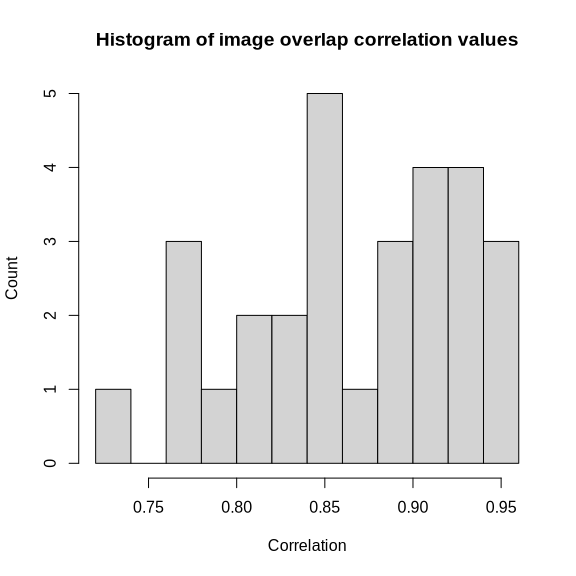

```r
hist(tmeta_df$corr, breaks = 10, main = "Histogram of image overlap correlation values",
     ylab = "Count", xlab = "Correlation")
```

Low values (for example, below 0.75) should raise suspicion and warrant a detailed look at the coordinate transformation, for example using `check_transform`. Here, a closer look at our image pair with the lowest correlation (0.72) suggests that the transformation parameters are indeed a bit off for that image. This indicates that more stringent parameters should be used when computing the transformation parameters. Here, it is not surprising that we struggle in finding good parameters since we are working with low-resolution images. Real-world datasets will not commonly suffer from this problem.

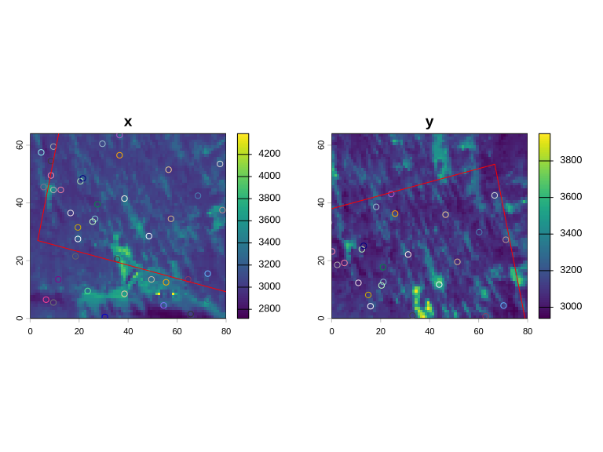

```r
# Setting the seed for reproducibility of the vignette
set.seed(1)

# Finding the image index with the lowest correlation
min_image <- which.min(tmeta_df$corr)

# Verifying the transformation parameters non-interactively
check_transform(x = terra::rast(tmeta_df[min_image - 1, "SourceFile"]),
                y = terra::rast(tmeta_df[min_image, "SourceFile"]),
                params = trans_params, n = 40)
```

### Correction based on image overlap

Once the transformation parameters are known and have been added to the metadata, `correct_thermal` can be invoked with `correction_type = "overlap"`. Instead of relying on a statistical model, this approach will use the transformation parameters computed above to determine overlapping sections of successive images. Adjustment factors will then be computed based on the difference between the mean of the images in the region where they overlap.

```r
overlap_tmeta <- correct_thermal(metadata = tmeta_df,
                                 correction_type = "overlap",
                                 output_dir = tmpdir,
                                 camera_tz = "Etc/GMT+5",
                                 display_tz = "Etc/GMT+4",
                                 tags = "minimal",
                                 overwrite_dst = TRUE,
                                 verbose = FALSE)
```

The plot of the mean of images in the corrected looks as follows after using overlap correction:

```
#> Computing thermal image means on the fly as they were not pre-computed...
```

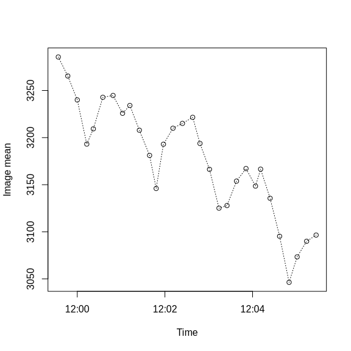

```r
plot_drift(overlap_tmeta)
```

As a cautionary note, we have found the overlap method to work well along straight flight lines, but not so much when the drone makes frequent turns. We suspect that this is because when the drone turns, the overlapping regions in successive images then come from very different locations on the sensor array. If the camera suffers from vignetting issues, the comparison of the overlapping sections of the images will be biased and error propagation becomes likely. In this case, overlap correction may worsen the results compared to no correction at all.

# Session info